# UnsupervisedML_assign3_Yiyun(Rona)Luo

```python
import numpy as np
import pandas as pd
import os
import matplotlib.pyplot as plt
import seaborn as sns
from pyod.models.knn import KNN
from pyod.utils.data import generate_data
from pyod.utils.data import evaluate_print
from pyod.utils.example import visualize
from pyod.models.iforest import IForest
```

```python
os.chdir('/Users/rona/Documents/anomalyDetection/week4/')
```

### Read the previous data with features created ("all_df")

```python
all_df= pd.read_csv('all_df.csv')
all_df.head()
```

|  | DRG.Definition | Provider.Id | Provider.Name | Provider.Street.Address | Provider.City | Provider.State | Provider.Zip.Code | Hospital.Referral.Region.Description | ratio_total_discharges_st | ratio_average_covered_charges_st | ... | pricey_DRG_ratio | common_DRG_ratio | ratio_total_discharges_national | ratio_average_covered_charges_national | ratio_average_total_payments_national | ratio_average_medicare_payments_national | ratio_total_discharges_city | ratio_average_covered_charges_city | ratio_average_total_payments_city | ratio_average_medicare_payments_city |
| --- | --- | --- | --- | --- | --- | --- | --- | --- | --- | --- | --- | --- | --- | --- | --- | --- | --- | --- | --- | --- | --- |
| 0 | 057 - DEGENERATIVE NERVOUS SYSTEM DISORDERS W/... | 100001 | SHANDS JACKSONVILLE MEDICAL CENTER | 655 W 8TH ST | JACKSONVILLE | FL | 32209 | FL - Jacksonville | 1.367678 | 0.937109 | ... | 2.769691 | 9.104586 | 1.510592 | 1.050820 | 1.220258 | 1.300305 | 1.727273 | 1.358694 | 1.455860 | 1.533954 |
| 1 | 064 - INTRACRANIAL HEMORRHAGE OR CEREBRAL INFA... | 100001 | SHANDS JACKSONVILLE MEDICAL CENTER | 655 W 8TH ST | JACKSONVILLE | FL | 32209 | FL - Jacksonville | 1.562709 | 0.862799 | ... | 2.769691 | 9.104586 | 1.549643 | 1.061030 | 1.215932 | 1.249082 | 1.208333 | 1.000000 | 1.392831 | 1.439040 |
| 2 | 065 - INTRACRANIAL HEMORRHAGE OR CEREBRAL INFA... | 100001 | SHANDS JACKSONVILLE MEDICAL CENTER | 655 W 8TH ST | JACKSONVILLE | FL | 32209 | FL - Jacksonville | 1.469287 | 0.812062 | ... | 2.769691 | 9.104586 | 1.663146 | 1.049594 | 1.280431 | 1.368281 | 1.695652 | 1.091813 | 1.380736 | 1.450070 |
| 3 | 066 - INTRACRANIAL HEMORRHAGE OR CEREBRAL INFA... | 100001 | SHANDS JACKSONVILLE MEDICAL CENTER | 655 W 8TH ST | JACKSONVILLE | FL | 32209 | FL - Jacksonville | 0.460185 | 0.774008 | ... | 2.769691 | 9.104586 | 0.517395 | 0.961681 | 1.237228 | 1.237469 | 0.457143 | 1.055997 | 1.364257 | 1.388005 |
| 4 | 069 - TRANSIENT ISCHEMIA | 100001 | SHANDS JACKSONVILLE MEDICAL CENTER | 655 W 8TH ST | JACKSONVILLE | FL | 32209 | FL - Jacksonville | 0.969739 | 0.896799 | ... | 2.769691 | 9.104586 | 1.232567 | 1.167613 | 1.257318 | 1.332711 | 1.219512 | 1.388727 | 1.335567 | 1.557252 |

5 rows × 22 columns

```python
all_df.shape
```

```
(163065, 22)
```

```python
# subset data that contain all features will be used in later analysis
ratio_df=all_df.iloc[:,8:]
ratio_df.shape
```

```
(163065, 14)
```

```python
ratio_df.head()
```

|  | ratio_total_discharges_st | ratio_average_covered_charges_st | ratio_average_total_payments_st | ratio_average_medicare_payments_st | pricey_DRG_ratio | common_DRG_ratio | ratio_total_discharges_national | ratio_average_covered_charges_national | ratio_average_total_payments_national | ratio_average_medicare_payments_national | ratio_total_discharges_city | ratio_average_covered_charges_city | ratio_average_total_payments_city | ratio_average_medicare_payments_city |
| --- | --- | --- | --- | --- | --- | --- | --- | --- | --- | --- | --- | --- | --- | --- |
| 0 | 1.367678 | 0.937109 | 1.431739 | 1.557789 | 2.769691 | 9.104586 | 1.510592 | 1.050820 | 1.220258 | 1.300305 | 1.727273 | 1.358694 | 1.455860 | 1.533954 |
| 1 | 1.562709 | 0.862799 | 1.364516 | 1.414058 | 2.769691 | 9.104586 | 1.549643 | 1.061030 | 1.215932 | 1.249082 | 1.208333 | 1.000000 | 1.392831 | 1.439040 |
| 2 | 1.469287 | 0.812062 | 1.419406 | 1.535602 | 2.769691 | 9.104586 | 1.663146 | 1.049594 | 1.280431 | 1.368281 | 1.695652 | 1.091813 | 1.380736 | 1.450070 |
| 3 | 0.460185 | 0.774008 | 1.376787 | 1.409637 | 2.769691 | 9.104586 | 0.517395 | 0.961681 | 1.237228 | 1.237469 | 0.457143 | 1.055997 | 1.364257 | 1.388005 |
| 4 | 0.969739 | 0.896799 | 1.364533 | 1.495945 | 2.769691 | 9.104586 | 1.232567 | 1.167613 | 1.257318 | 1.332711 | 1.219512 | 1.388727 | 1.335567 | 1.557252 |

### Take a look about variables correlation

```python
ratio_df.corr()
```

|  | ratio_total_discharges_st | ratio_average_covered_charges_st | ratio_average_total_payments_st | ratio_average_medicare_payments_st | pricey_DRG_ratio | common_DRG_ratio | ratio_total_discharges_national | ratio_average_covered_charges_national | ratio_average_total_payments_national | ratio_average_medicare_payments_national | ratio_total_discharges_city | ratio_average_covered_charges_city | ratio_average_total_payments_city | ratio_average_medicare_payments_city |
| --- | --- | --- | --- | --- | --- | --- | --- | --- | --- | --- | --- | --- | --- | --- |
| ratio_total_discharges_st | 1.000000 | 0.102910 | 0.081703 | 0.060423 | 0.587930 | 0.606193 | 0.932062 | 0.060843 | 0.062976 | 0.045346 | 0.535731 | 0.053657 | 0.034284 | 0.021181 |
| ratio_average_covered_charges_st | 0.102910 | 1.000000 | 0.316242 | 0.273595 | 0.168036 | 0.118476 | 0.092261 | 0.709455 | 0.260082 | 0.222812 | 0.052884 | 0.467182 | 0.151980 | 0.124384 |
| ratio_average_total_payments_st | 0.081703 | 0.316242 | 1.000000 | 0.895806 | 0.183135 | 0.066264 | 0.080008 | 0.219784 | 0.827327 | 0.730430 | 0.056774 | 0.167088 | 0.577896 | 0.514617 |
| ratio_average_medicare_payments_st | 0.060423 | 0.273595 | 0.895806 | 1.000000 | 0.154743 | 0.038315 | 0.061309 | 0.190942 | 0.743308 | 0.809324 | 0.046048 | 0.143437 | 0.519524 | 0.573519 |
| pricey_DRG_ratio | 0.587930 | 0.168036 | 0.183135 | 0.154743 | 1.000000 | 0.814672 | 0.561148 | 0.134405 | 0.168986 | 0.145223 | 0.325050 | 0.120699 | 0.096027 | 0.079179 |
| common_DRG_ratio | 0.606193 | 0.118476 | 0.066264 | 0.038315 | 0.814672 | 1.000000 | 0.574916 | 0.078622 | 0.063118 | 0.040560 | 0.312814 | 0.060631 | 0.001146 | -0.012621 |
| ratio_total_discharges_national | 0.932062 | 0.092261 | 0.080008 | 0.061309 | 0.561148 | 0.574916 | 1.000000 | 0.033250 | 0.067335 | 0.057749 | 0.524520 | 0.051270 | 0.030691 | 0.018479 |
| ratio_average_covered_charges_national | 0.060843 | 0.709455 | 0.219784 | 0.190942 | 0.134405 | 0.078622 | 0.033250 | 1.000000 | 0.313045 | 0.291500 | 0.031057 | 0.400248 | 0.120768 | 0.105525 |
| ratio_average_total_payments_national | 0.062976 | 0.260082 | 0.827327 | 0.743308 | 0.168986 | 0.063118 | 0.067335 | 0.313045 | 1.000000 | 0.928615 | 0.049549 | 0.153580 | 0.493275 | 0.444329 |
| ratio_average_medicare_payments_national | 0.045346 | 0.222812 | 0.730430 | 0.809324 | 0.145223 | 0.040560 | 0.057749 | 0.291500 | 0.928615 | 1.000000 | 0.041275 | 0.133489 | 0.436151 | 0.479142 |
| ratio_total_discharges_city | 0.535731 | 0.052884 | 0.056774 | 0.046048 | 0.325050 | 0.312814 | 0.524520 | 0.031057 | 0.049549 | 0.041275 | 1.000000 | 0.084575 | 0.046588 | 0.032037 |
| ratio_average_covered_charges_city | 0.053657 | 0.467182 | 0.167088 | 0.143437 | 0.120699 | 0.060631 | 0.051270 | 0.400248 | 0.153580 | 0.133489 | 0.084575 | 1.000000 | 0.278254 | 0.242035 |
| ratio_average_total_payments_city | 0.034284 | 0.151980 | 0.577896 | 0.519524 | 0.096027 | 0.001146 | 0.030691 | 0.120768 | 0.493275 | 0.436151 | 0.046588 | 0.278254 | 1.000000 | 0.890013 |
| ratio_average_medicare_payments_city | 0.021181 | 0.124384 | 0.514617 | 0.573519 | 0.079179 | -0.012621 | 0.018479 | 0.105525 | 0.444329 | 0.479142 | 0.032037 | 0.242035 | 0.890013 | 1.000000 |

```python
ratio_df.columns
```

```
Index(['ratio_total_discharges_st', 'ratio_average_covered_charges_st',
       'ratio_average_total_payments_st', 'ratio_average_medicare_payments_st',
       'pricey_DRG_ratio', 'common_DRG_ratio',
       'ratio_total_discharges_national',
       'ratio_average_covered_charges_national',
       'ratio_average_total_payments_national',
       'ratio_average_medicare_payments_national',
       'ratio_total_discharges_city', 'ratio_average_covered_charges_city',
       'ratio_average_total_payments_city',
       'ratio_average_medicare_payments_city'],
      dtype='object')
```

### Correlation Matrix

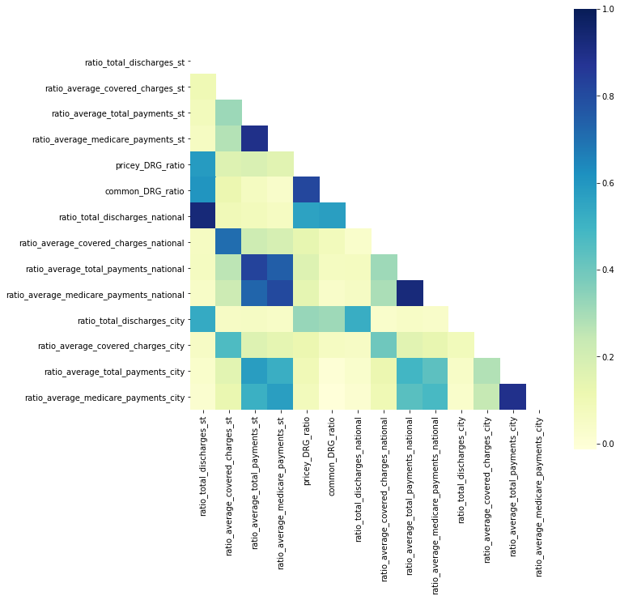

```python
f, ax = plt.subplots(figsize=(10,10))
corr = ratio_df.corr()
mask = np.zeros_like(corr, dtype=np.bool)
mask[np.triu_indices_from(mask)] = True
sns.heatmap(corr, mask=mask,cmap="YlGnBu",square=True, ax=ax)
```

From the correlation matrix, I know that "ratio_average_medicare_payments_st" and "ratio_average_total_payments_st", "ratio_total_discharges_national" and "ratio_total_discharges_st", "common_DRG_ratio" and "pricy_DRG_ratio", "ratio_average_total_payments_national" and "ratio_average_total_payments_st", ratio_average_medicare_payments_national" and "ratio_average_medicare_payments_st", "ratio_average_medicare_payments_national" and "ratio_average_total_payments_national" are highly correlated.

# PCA with all ratio data

- To reduce the demension and better interpret data, I use PCA before modeling
- 7 Components have been set and could represent about 92% variance

```python
from sklearn.model_selection import train_test_split
from sklearn.preprocessing import StandardScaler
from sklearn.decomposition import PCA
```

```python
scaled_data = StandardScaler().fit_transform(ratio_df)
scaled_data=pd.DataFrame(scaled_data, columns=ratio_df.columns.tolist())
scaled_data.head()
```

|  | ratio_total_discharges_st | ratio_average_covered_charges_st | ratio_average_total_payments_st | ratio_average_medicare_payments_st | pricey_DRG_ratio | common_DRG_ratio | ratio_total_discharges_national | ratio_average_covered_charges_national | ratio_average_total_payments_national | ratio_average_medicare_payments_national | ratio_total_discharges_city | ratio_average_covered_charges_city | ratio_average_total_payments_city | ratio_average_medicare_payments_city |
| --- | --- | --- | --- | --- | --- | --- | --- | --- | --- | --- | --- | --- | --- | --- |
| 0 | 0.535908 | -0.165874 | 2.210950 | 2.593272 | -0.114817 | 1.129065 | 0.671770 | 0.092017 | 0.887215 | 1.067280 | 1.108562 | 1.326864 | 3.691537 | 3.889179 |
| 1 | 0.820174 | -0.361863 | 1.866698 | 1.925038 | -0.114817 | 1.129065 | 0.723148 | 0.110505 | 0.869789 | 0.885232 | 0.235532 | -0.078887 | 3.168170 | 3.180726 |
| 2 | 0.684008 | -0.495681 | 2.147792 | 2.490122 | -0.114817 | 1.129065 | 0.872480 | 0.089798 | 1.129593 | 1.308864 | 1.055365 | 0.280935 | 3.067736 | 3.263057 |
| 3 | -0.786805 | -0.596048 | 1.929538 | 1.904484 | -0.114817 | 1.129065 | -0.634948 | -0.069382 | 0.955568 | 0.843960 | -1.028222 | 0.140571 | 2.930908 | 2.799790 |
| 4 | -0.044107 | -0.272190 | 1.866788 | 2.305748 | -0.114817 | 1.129065 | 0.305981 | 0.303488 | 1.036496 | 1.182449 | 0.254339 | 1.444566 | 2.692679 | 4.063080 |

```python
pca = PCA(n_components=7)
principalComponents = pca.fit_transform(scaled_data)
print(pca.n_components_,"components have been set in the model")
```

```
7 components have been set in the model
```

```python
components_df=pd.DataFrame(principalComponents)
components_df.columns=['PC1','PC2',"PC3","PC4","PC5",'PC6','PC7']
print(components_df.shape)
components_df.head()
```

```
(163065, 7)
```

|  | PC1 | PC2 | PC3 | PC4 | PC5 | PC6 | PC7 |
| --- | --- | --- | --- | --- | --- | --- | --- |
| 0 | 5.598466 | -0.570084 | -1.647276 | 3.239395 | -0.020729 | -0.080737 | 0.313987 |
| 1 | 4.431455 | -0.373059 | -2.004130 | 2.179101 | -0.452603 | -1.126014 | 0.148720 |
| 2 | 5.125970 | -0.302742 | -2.171556 | 2.074061 | 0.146822 | -0.472417 | 0.397878 |
| 3 | 3.699700 | -2.109820 | -1.710558 | 1.680174 | -1.812709 | -0.389659 | 0.306455 |
| 4 | 5.015258 | -1.140010 | -1.223890 | 2.703610 | -0.665680 | 0.081645 | 0.112719 |

```python
print("7 components represent", format(pca.explained_variance_ratio_.sum()*100,".4") + "%", "variance")
```

```
7 components represent 91.81% variance
```

```python
data = {'Components':components_df.columns, 'Variance':pca.explained_variance_ratio_.tolist()}
pca_components=pd.DataFrame(data)
pca_components=pca_components.set_index('Components')
pca_components
```

| Components | Variance |
| --- | --- |
| PC1 | 0.340707 |
| PC2 | 0.231436 |
| PC3 | 0.124671 |
| PC4 | 0.083295 |
| PC5 | 0.061592 |
| PC6 | 0.040346 |
| PC7 | 0.036076 |

### Inspect Components

Contributions of each variable to each component shows below:

```python
comp_inspect=pd.DataFrame(pca.components_,columns=ratio_df.columns.tolist() ).transpose()
comp_inspect.columns=['PC1','PC2',"PC3","PC4","PC5",'PC6','PC7']
comp_inspect
```

|  | PC1 | PC2 | PC3 | PC4 | PC5 | PC6 | PC7 |
| --- | --- | --- | --- | --- | --- | --- | --- |
| ratio_total_discharges_st | 0.136476 | 0.475854 | -0.081271 | 0.038233 | 0.193495 | -0.236025 | -0.355701 |
| ratio_average_covered_charges_st | 0.210592 | 0.022702 | 0.579906 | -0.053571 | 0.034704 | -0.261781 | 0.040608 |
| ratio_average_total_payments_st | 0.395944 | -0.122275 | -0.114899 | -0.166905 | 0.023210 | 0.053716 | -0.076935 |
| ratio_average_medicare_payments_st | 0.388129 | -0.137395 | -0.145219 | -0.168781 | 0.036528 | 0.056730 | -0.082600 |
| pricey_DRG_ratio | 0.179526 | 0.398288 | -0.012228 | -0.059032 | -0.482806 | 0.160383 | 0.221539 |
| common_DRG_ratio | 0.123106 | 0.428904 | -0.018848 | -0.069050 | -0.495236 | 0.113591 | 0.192985 |
| ratio_total_discharges_national | 0.133571 | 0.466647 | -0.094553 | 0.035510 | 0.220386 | -0.230216 | -0.415093 |
| ratio_average_covered_charges_national | 0.193340 | -0.001479 | 0.579887 | -0.123840 | 0.048898 | -0.342027 | 0.239690 |
| ratio_average_total_payments_national | 0.387933 | -0.125504 | -0.087346 | -0.300103 | 0.058503 | 0.119733 | -0.019397 |
| ratio_average_medicare_payments_national | 0.377946 | -0.135019 | -0.108647 | -0.308746 | 0.073234 | 0.125864 | -0.027133 |
| ratio_total_discharges_city | 0.098418 | 0.325407 | -0.067243 | 0.129251 | 0.633309 | 0.292210 | 0.607105 |
| ratio_average_covered_charges_city | 0.165134 | 0.005009 | 0.452403 | 0.390632 | 0.011685 | 0.671816 | -0.385371 |
| ratio_average_total_payments_city | 0.316942 | -0.134808 | -0.143459 | 0.533195 | -0.099845 | -0.199507 | 0.106357 |
| ratio_average_medicare_payments_city | 0.310258 | -0.144205 | -0.167019 | 0.524873 | -0.100944 | -0.233129 | 0.116182 |

### Visulization of contributions of each variable to each component

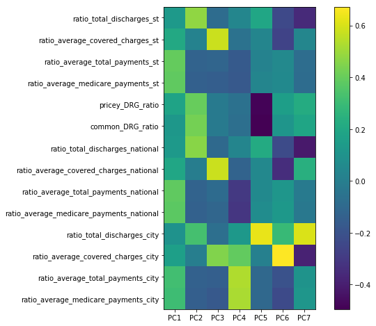

```python
fig=plt.figure(figsize=(10,8))
ax=fig.add_subplot(1,1,1)
components = pca.components_
plt.imshow(components.T)
plt.yticks(range(len(scaled_data.columns)), scaled_data.columns)
plt.xticks(range(len(comp_inspect.columns)), comp_inspect.columns)
plt.colorbar()
```

### Insights

Based on the analysis above, I got to know the contribution of each variable in the 7 components. The results show that in PC3, ratio_average_covered_charges_national and ratio_average_covered_charges_st contribute the most; In PC5 and PC7, ratio_total_discharges_city contributes a lot; pricy_DRG_ratio and common_DRG_ratio contribute a lot in PC5, etc. This infomation could help in later ML results interpretation.

# Isolation Forest

```python
X_train, X_test = train_test_split(components_df, test_size=0.3, random_state=123)
print(X_train.shape)
```

```
(114145, 7)
```

```python
clf_isof = IForest(behaviour="new")
clf_isof.fit(X_train)
```

```
IForest(behaviour='new', bootstrap=False, contamination=0.1, max_features=1.0,
    max_samples='auto', n_estimators=100, n_jobs=1, random_state=None,
    verbose=0)
```

```python
y_test_scores_isof = clf_isof.decision_function(X_test)  # outlier scores
y_test_scores_isof = pd.Series(y_test_scores_isof)
```

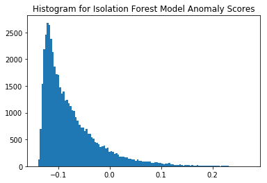

```python
plt.hist(y_test_scores_isof, bins='auto')  # arguments are passed to np.histogram
plt.title("Histogram for Isolation Forest Model Anomaly Scores")
plt.show()
```

Choose 0.15 as cut point in this case; Those with score greater than or equal to 0.15 will be considered as outliners.

```python
X_test_isof_cluster = X_test.copy()
X_test_isof_cluster['distance'] = y_test_scores_isof.values
X_test_isof_cluster['cluster'] = np.where(X_test_isof_cluster['distance']<0.15, 0, 1)
X_test_isof_cluster['cluster'].value_counts()
```

```
0    48663
1      257
Name: cluster, dtype: int64
```

```python
isof_df=X_test_isof_cluster['cluster'].value_counts().to_frame().reset_index()
isof_df.columns = ["cluster", 'observation']
isof_df=isof_df.set_index('cluster')
print(isof_df, "\n")
print("Observations in cluster1 would be considered as outliners, which count",
      format(100*isof_df.observation[1]/X_test_isof_cluster.shape[0],".3f") + "%","in the whole dataset.")
```

```
         observation
cluster
0              48663
1                257

Observations in cluster1 would be considered as outliners, which count 0.525% in the whole dataset.
```

```python
X_test_isof_cluster.groupby('cluster').mean()
```

| cluster | PC1 | PC2 | PC3 | PC4 | PC5 | PC6 | PC7 | distance |
| --- | --- | --- | --- | --- | --- | --- | --- | --- |
| 0 | -0.039205 | -0.020334 | -0.002250 | -0.014997 | -0.019230 | -0.018017 | -0.002131 | -0.076694 |
| 1 | 6.396001 | 3.813916 | 1.376139 | 2.168733 | 3.367643 | 2.809408 | 0.875928 | 0.183936 |

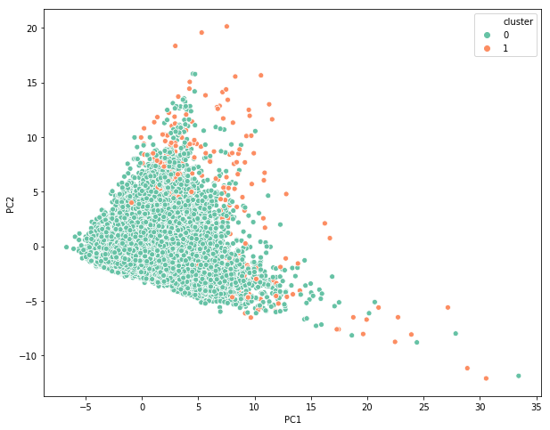

```python
fig=plt.figure(figsize=(10,8))
ax=fig.add_subplot(1,1,1)
sns.scatterplot(x=X_test_isof_cluster.iloc[:, 0], y=X_test_isof_cluster.iloc[:, 1], hue=X_test_isof_cluster.cluster, palette="Set2")
plt.show()
```

## Aggregate to Achieve Model Stability

```python
from pyod.models.combination import aom, moa, average, maximization
from pyod.utils.utility import standardizer
```

```python
train_scores= clf_isof.decision_scores_.reshape(-1, 1)
test_scores = clf_isof.decision_function(X_test).reshape(-1, 1)
train_scores_norm, test_scores_norm = standardizer(train_scores,test_scores)
print("train_scores_norm's shape:", train_scores_norm.shape, "\n" "test_scores_norm's shape:", test_scores_norm.shape)
```

```
train_scores_norm's shape: (114145, 1)
test_scores_norm's shape: (48920, 1)
```

### Average Method

Combination method to merge the outlier scores from multiple estimators by taking the average.

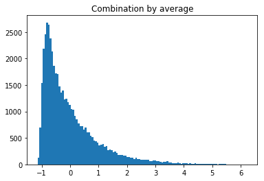

```python
# Combination by average
y_by_average = average(test_scores_norm)

plt.hist(y_by_average, bins='auto')
plt.title("Combination by average")
plt.show()
```

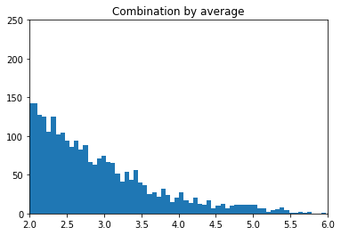

```python
plt.hist(y_by_average, bins='auto')
plt.title("Combination by average")
plt.xlim(2,6)
plt.ylim(0,250)
plt.show()
```

identify those >=4.0 as the outliers

```python
df_test_iso_avg = X_test.copy()
df_test_iso_avg['y_by_average_score'] = y_by_average
df_test_iso_avg['y_by_average_cluster'] = np.where(df_test_iso_avg['y_by_average_score']<4.0, 0, 1)
df_test_iso_avg['y_by_average_cluster'].value_counts()
```

```
0    48652
1      268
Name: y_by_average_cluster, dtype: int64
```

```python
isof_avg_df=df_test_iso_avg['y_by_average_cluster'].value_counts().to_frame().reset_index()
isof_avg_df.columns = ["cluster", 'observation']
isof_avg_df=isof_avg_df.set_index('cluster')
print(isof_avg_df, "\n")
print("Observations in cluster1 would be considered as outliners, which count",
      format(100*isof_avg_df.observation[1]/X_test_isof_cluster.shape[0],".3f") + "%", "in the whole dataset")
```

```
         observation
cluster
0              48652
1                268

Observations in cluster1 would be considered as outliners, which count 0.548% in the whole dataset
```

```python
df_test_iso_avg.groupby('y_by_average_cluster').mean()
```

| y_by_average_cluster | PC1 | PC2 | PC3 | PC4 | PC5 | PC6 | PC7 | y_by_average_score |
| --- | --- | --- | --- | --- | --- | --- | --- | --- |
| 0 | -0.040863 | -0.020513 | -0.002395 | -0.015552 | -0.019661 | -0.018248 | -0.002370 | -0.027344 |
| 1 | 6.432898 | 3.689037 | 1.345962 | 2.179840 | 3.306870 | 2.735230 | 0.883387 | 4.615021 |

### Business Insights

- The higher the score is the more the abnormal;
- Healthcare providers in Cluster1 are highly suspicious;
- The score of cluster1 is greater than that of cluster0 in a great degree; Specifically, PC1 and PC2 attract me a lot;
- Based on the components interpretation above, ratio_average_total_payments_st, ratio_average_total_payments_national and ratio_average_total_payments_city contribute a lot, which means those healthcare providers inpacient charges is way much higher than the based line in their states and cities.

### Visulization

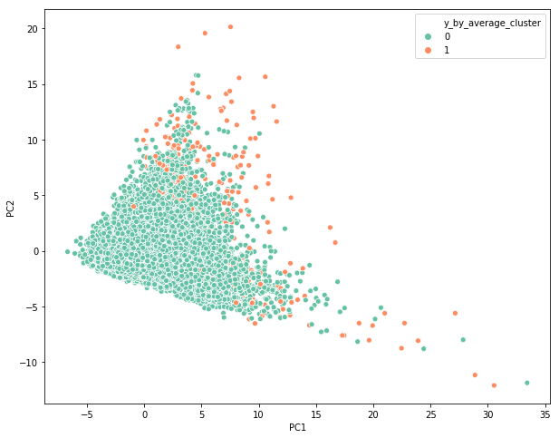

```python
fig=plt.figure(figsize=(10,8))
ax=fig.add_subplot(1,1,1)
sns.scatterplot(x=df_test_iso_avg.iloc[:, 0], y=df_test_iso_avg.iloc[:, 1], hue=df_test_iso_avg.y_by_average_cluster, palette="Set2")
plt.show()
```

## Comparison

- Compare the stabalized isolation forest model with the Isolation forest without stabilization;
- Plot the first two dimensions of the models

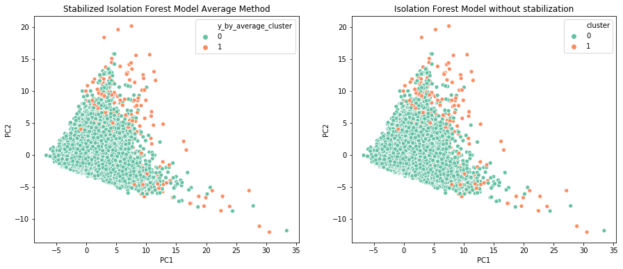

```python
plt.figure(figsize=(15,6))

plt.subplot(1, 2, 1)
sns.scatterplot(x=df_test_iso_avg.iloc[:, 0], y=df_test_iso_avg.iloc[:, 1], hue=df_test_iso_avg.y_by_average_cluster, palette="Set2")
plt.title('Stabilized Isolation Forest Model Average Method')

plt.subplot(1,2,2)
sns.scatterplot(x=X_test_isof_cluster.iloc[:, 0], y=X_test_isof_cluster.iloc[:, 1], hue=X_test_isof_cluster.cluster, palette="Set2")
plt.title("Isolation Forest Model without stabilization")

plt.show()
```

Plot with 2 dimensions; Based on the above plots, I could not directly see the difference between the Isolation Forest Model aggregated with Average Method and the original Isolation Forest Model. But from the detials of the isolation forest model before stabalization and after, I could see the difference of two clusters' score in Isolation Forest with Average Method is larger and more distinguishable.

### Everything below is from the last assignment. Leave here for comparison

# k-Nearest Neighbors Detector (KNN)

Split data into X_train (70% of the data) and X_test (30% of the data), and conduct KNN for outliner detection

```python
X_train, X_test = train_test_split(components_df, test_size=0.3, random_state=123)
```

```python
clf_name = 'KNN'
clf = KNN()
clf.fit(X_train)
```

```
KNN(algorithm='auto', contamination=0.1, leaf_size=30, method='largest',
  metric='minkowski', metric_params=None, n_jobs=1, n_neighbors=5, p=2,
  radius=1.0)
```

```python
y_train_pred = clf.labels_
y_train_scores = clf.decision_scores_
```

```python
y_test_pred = clf.predict(X_test)
y_test_scores = clf.decision_function(X_test)
```

```python
y_test_scores.mean()
```

```
0.5699662145622988
```

### I choose 2.5 as the cutpoint and suggest those >=2.5 to be outliers

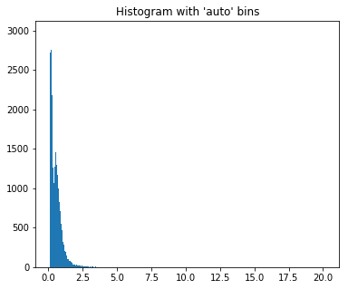

```python
plt.figure(figsize=(6,5))
plt.hist(y_test_scores, bins="auto")
plt.title("Histogram with 'auto' bins")
plt.show()
```

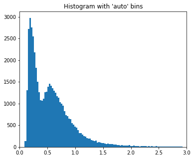

```python
plt.figure(figsize=(6,5))
plt.hist(y_test_scores, bins="auto")
plt.title("Histogram with 'auto' bins")
plt.xlim(0, 3)
plt.show()
```

```python
df_test_0 = pd.DataFrame(X_test)
df_test=df_test_0.copy()
df_test['score'] = y_test_scores
df_test['cluster'] = np.where(df_test['score']<2.5, 0, 1)
df_test['cluster'].value_counts()
```

```
0    48631
1      289
Name: cluster, dtype: int64
```

```python
print("Suspicious healthcare providers count for", format((289/(48631+289)) *100,"0.3") +"%", "in the test dataset.")
```

```
Suspicious healthcare providers count for 0.591% in the test dataset.
```

```python
df_test.groupby('cluster').mean()
```

| cluster | PC1 | PC2 | PC3 | PC4 | PC5 | PC6 | PC7 | score |
| --- | --- | --- | --- | --- | --- | --- | --- | --- |
| 0 | -0.052894 | -0.017698 | -0.000400 | -0.013432 | -0.017565 | -0.012597 | -0.001419 | 0.551077 |
| 1 | 7.986858 | 2.945874 | 0.912228 | 1.663530 | 2.712430 | 1.584204 | 0.658862 | 3.748509 |

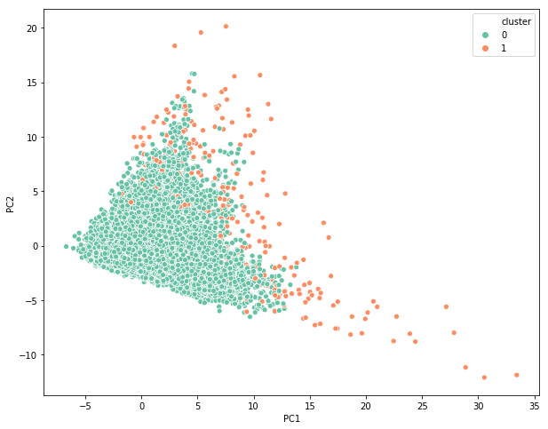

```python
fig=plt.figure(figsize=(10,8))
ax=fig.add_subplot(1,1,1)
sns.scatterplot(x=df_test.iloc[:, 0], y=df_test.iloc[:, 1], hue=df_test.cluster, palette="Set2")
plt.show()
```

### Conclusion

I identify observation in cluster 1 as outliners. Those 289 healthcare providers in cluster 1 are highly suspicious. And, from the above picture, which represents the first two components, we could see ouliners plot in orange points.

## Achieve Model Stability by Aggregating Maximum of Average (MOA)

```python
# test a range of n_neighbors from 10 to 200
n_clf = 20
k_list = [10, 20, 30, 40, 50, 60, 70, 80, 90, 100, 110, 120, 130, 140, 150, 160, 170, 180, 190, 200]
# Just prepare data frames so we can store the model results
train_scores = np.zeros([X_train.shape[0], n_clf])
test_scores = np.zeros([X_test.shape[0], n_clf])
print(train_scores.shape)
print(test_scores.shape)
```

```
(114145, 20)
(48920, 20)
```

```python
for i in range(n_clf):
    k = k_list[i]
    clf = KNN(n_neighbors=k, method='largest')
    clf.fit(X_train)
    train_scores[:, i] = clf.decision_scores_
    test_scores[:, i] = clf.decision_function(X_test.iloc[:,0:7])
```

```python
#Standardize data
train_scores_norm, test_scores_norm = standardizer(train_scores,test_scores)
```

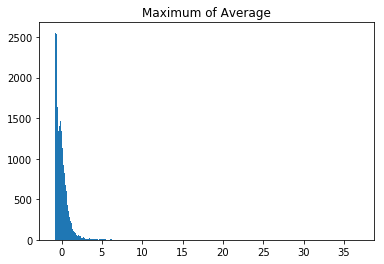

```python
# Combination by moa
y_by_moa = moa(test_scores_norm, n_buckets=5)

plt.hist(y_by_moa, bins='auto')  # arguments are passed to np.histogram
plt.title("Maximum of Average")
plt.show()
```

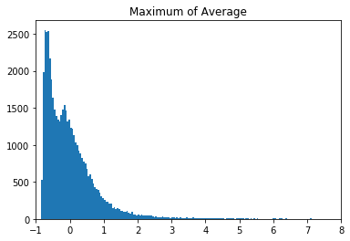

```python
#zoom in to identify the cutpoint
plt.hist(y_by_moa, bins='auto')
plt.title("Maximum of Average")
plt.xlim(-1, 8)
plt.show()
```

See from the above graph , I identify those >=5.0 as the outliers

```python
df_tamp = pd.DataFrame(X_test)
df_test1=df_tamp.copy()
df_test1['y_by_moa_score'] = y_by_moa
df_test1['y_by_moa_cluster'] = np.where(df_test1['y_by_moa_score']<5.0, 0, 1)
df_test1['y_by_moa_cluster'].value_counts()
```

```
0    48729
1      191
Name: y_by_moa_cluster, dtype: int64
```

Consider observation in cluster1 as outliners

```python
df_test1.groupby('y_by_moa_cluster').mean()
```

| y_by_moa_cluster | PC1 | PC2 | PC3 | PC4 | PC5 | PC6 | PC7 | y_by_moa_score |
| --- | --- | --- | --- | --- | --- | --- | --- | --- |
| 0 | -0.043359 | -0.011205 | -0.000463 | -0.011161 | -0.013108 | -0.011501 | 0.001095 | -0.011259 |
| 1 | 9.679448 | 2.809786 | 1.396471 | 1.944612 | 2.976039 | 2.123890 | 0.356273 | 7.882223 |

```python
print("Suspicious healthcare providers count for", format((191/(48729+191)) *100,"0.3") +"%", "in the test dataset.")
```

```
Suspicious healthcare providers count for 0.39% in the test dataset.
```

# Visualization

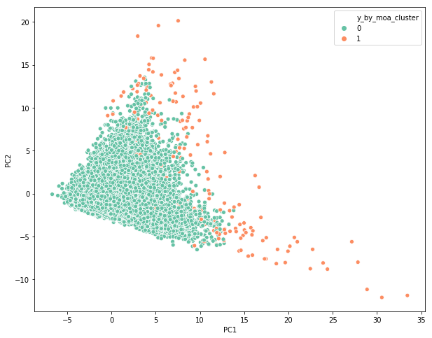

```python
fig=plt.figure(figsize=(10,8))
ax=fig.add_subplot(1,1,1)
sns.scatterplot(x=df_test1.iloc[:, 0], y=df_test1.iloc[:, 1], hue=df_test1.y_by_moa_cluster, palette="Set2")
plt.show()
```

I identify observation in cluster 1 as outliners. Those 191 healthcare providers in cluster 1 are highly suspicious. And, from the above picture, which represents the first two components, we could see ouliners plot in orange points.

## Comparison

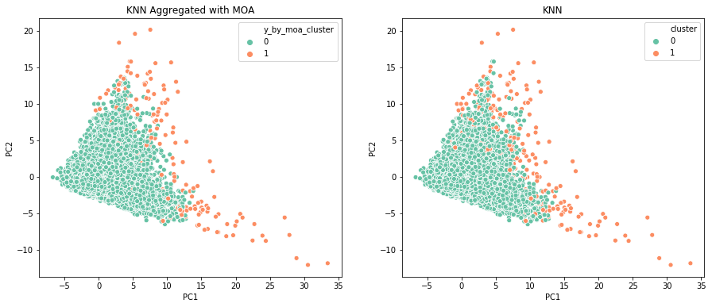

```python
plt.figure(figsize=(15,6))

plt.subplot(1, 2, 1)
sns.scatterplot(x=df_test1.iloc[:, 0], y=df_test1.iloc[:, 1], hue=df_test1.y_by_moa_cluster, palette="Set2")
plt.title('KNN Aggregated with MOA')


plt.subplot(1,2,2)
sns.scatterplot(x=X_test.iloc[:, 0], y=X_test.iloc[:, 1], hue=df_test.cluster, palette="Set2")
plt.title("KNN")

plt.show()
```

Plot with 2 dimensions; The knn results with MOA model could be consider better. 1). the picture: KNN aggregated with MOA has less overlap between cluster0 and cluster1 2). the difference of two clusters' score in knn with MOA is larger and more distinguishable.

```python
#END
```